# AgingStudy_analysisplan

```r
# Change here to change filtering criteria
df = df %>%
  filter(Exclusion != 'exc') # remove the excluded participatns
  #filter(Exclusion != 'out') # uncomment when removing outliers

# Contrast code Age groups
df$Age = as.factor(df$Age)
df = mutate(df, coded_Age = Age)
contrasts(df$coded_Age) = contr.treatment(2)

df$Gender = as.factor(df$Gender)
df = mutate(df, coded_Gender = Gender)
contrasts(df$coded_Gender) = contr.treatment(2)

df$Counterbalance = as.factor(df$Counterbalance)
df = mutate(df, coded_Counterbalance = Counterbalance)
contrasts(df$coded_Counterbalance) = contr.treatment(2)
```

### Hypothesis

Pattern separation and statistical learning are two independent processes. Aging, which typically impaires the dentate gyrus and pattern separation, does not affect statistical learning which does not depend on the dentate gyrus.

**Prediction**: Older adults will be significantly worse at *lure discrimination* (but not recognition) on the auditory MST task compared to younger adults, but will perform just as well as the younger adults on the statistical learning task.

### Sample size calculation (GPower)

```
F tests - ANOVA: Fixed effects, omnibus, one-way
Analysis: A priori: Compute required sample size
Input: Effect size f = 0.4200840
α err prob = 0.05
Power (1-β err prob) = 0.80
Number of groups = 2
Output: Noncentrality parameter λ = 8.4705872
Critical F = 4.0517487
Numerator df = 1
Denominator df = 46
Total sample size   =   48
Actual power = 0.8130553
```

**= 24 + 4 subjects per age group** to achieve 80% power to detect a large effect size (f = 0.42, from the literature)

### Primary analysis

Variables of interest: - Age group (1-4) - Lure discrimination (1) - Familiarity rating (2) - AFC accuracy (3) - Reaction time (4)

Control variables (included in the full model): - Gender - Counterbalance condition - Randomization condition (both MST and SL) - Occurrence (for RT)

1. Group difference in lure discrimination

```r
# Run GLM
discrimination_full = lm(Disc ~ coded_Age + coded_Gender + coded_Counterbalance, data = df)
discrimination_reduced = lm(Disc ~ coded_Age, data = df)
summary(discrimination_reduced)
```

```
##
## Call:
## lm(formula = Disc ~ coded_Age, data = df)
##
## Residuals:
##     Min      1Q  Median      3Q     Max
## -1.3072 -0.4427 -0.1187  0.2795  1.9180
##
## Coefficients:
##             Estimate Std. Error t value Pr(>|t|)
## (Intercept)   1.2378     0.1695   7.303 2.66e-08 ***
## coded_Age2    0.1181     0.2329   0.507    0.615
## ---
## Signif. codes:  0 '***' 0.001 '**' 0.01 '*' 0.05 '.' 0.1 ' ' 1
##
## Residual standard error: 0.6779 on 32 degrees of freedom
## Multiple R-squared:  0.007976,   Adjusted R-squared:  -0.02302
## F-statistic: 0.2573 on 1 and 32 DF,  p-value: 0.6155
```

```r
summary(discrimination_full)
```

```
##
## Call:
## lm(formula = Disc ~ coded_Age + coded_Gender + coded_Counterbalance,
##     data = df)
##
## Residuals:
##     Min      1Q  Median      3Q     Max
## -0.9469 -0.4204 -0.1073  0.3623  1.4246
##
## Coefficients:
##                       Estimate Std. Error t value Pr(>|t|)
## (Intercept)            0.87745    0.18882   4.647  6.3e-05 ***
## coded_Age2             0.01115    0.21379   0.052  0.95876
## coded_Gender2          0.27987    0.21450   1.305  0.20189
## coded_Counterbalance2  0.62364    0.20731   3.008  0.00528 **
## ---
## Signif. codes:  0 '***' 0.001 '**' 0.01 '*' 0.05 '.' 0.1 ' ' 1
##
## Residual standard error: 0.602 on 30 degrees of freedom
## Multiple R-squared:  0.2666, Adjusted R-squared:  0.1932
## F-statistic: 3.634 on 3 and 30 DF,  p-value: 0.02388
```

```r
anova(discrimination_full, discrimination_reduced)
```

|  | Res.Df | RSS | Df | Sum of Sq | F | Pr(>F) |
| --- | --- | --- | --- | --- | --- | --- |
| 1 | 30 | 10.87338 | NA | NA | NA | NA |
| 2 | 32 | 14.70688 | -2 | -3.833499 | 5.288372 | 0.01078105 |

```r
disc_anova = aov(Disc ~ coded_Age, data = df)
summary(disc_anova)
```

```
##             Df Sum Sq Mean Sq F value Pr(>F)
## coded_Age    1  0.118  0.1182   0.257  0.615
## Residuals   32 14.707  0.4596
```

2. Group difference in Familiarity rating

```r
df = mutate(df, fam_rating_diff = Word - Nonword)
longer_df = pivot_longer(df, cols=ends_with('ord'), names_to = 'word_type', values_to = 'ratings')
longer_df$word_type = as.factor(longer_df$word_type)
contrasts(longer_df$word_type) = contr.treatment(3, base=1)
# Run linear mixed model with subject as random effects
familiarity_full = lmer(ratings ~ word_type*coded_Age + coded_Gender + coded_Counterbalance + (1|Subject),
                        data = longer_df)
familiarity_model = lmer(ratings ~ word_type + coded_Age + (1|Subject), data = longer_df)
summary(familiarity_full)
```

```
## Linear mixed model fit by REML. t-tests use Satterthwaite's method [
## lmerModLmerTest]
## Formula:
## ratings ~ word_type * coded_Age + coded_Gender + coded_Counterbalance +
##     (1 | Subject)
##    Data: longer_df
##
## REML criterion at convergence: 163.2
##
## Scaled residuals:
##     Min      1Q  Median      3Q     Max
## -3.1662 -0.6029  0.1159  0.5888  1.6465
##
## Random effects:
##  Groups   Name        Variance Std.Dev.
##  Subject  (Intercept) 0.1317   0.3629
##  Residual             0.1785   0.4225
## Number of obs: 102, groups:  Subject, 34
##
## Fixed effects:
##                       Estimate Std. Error      df t value Pr(>|t|)
## (Intercept)             2.8109     0.1620 54.4240  17.351  < 2e-16 ***
## word_type2              0.2187     0.1494 64.0000   1.465  0.14794
## word_type3              0.4844     0.1494 64.0000   3.243  0.00188 **
## coded_Age2             -0.2009     0.1953 64.8217  -1.028  0.30754
## coded_Gender2          -0.1435     0.1558 30.0000  -0.921  0.36433
## coded_Counterbalance2   0.1061     0.1506 30.0000   0.704  0.48662
## word_type2:coded_Age2  -0.1910     0.2053 64.0000  -0.930  0.35572
## word_type3:coded_Age2   0.2378     0.2053 64.0000   1.159  0.25091
## ---
## Signif. codes:  0 '***' 0.001 '**' 0.01 '*' 0.05 '.' 0.1 ' ' 1
##
## Correlation of Fixed Effects:
##             (Intr) wrd_t2 wrd_t3 cdd_A2 cdd_G2 cdd_C2 w_2:_A
## word_type2  -0.461
## word_type3  -0.461  0.500
## coded_Age2  -0.533  0.382  0.382
## coded_Gndr2 -0.310  0.000  0.000 -0.195
## cdd_Cntrbl2 -0.414  0.000  0.000 -0.053  0.023
## wrd_ty2:_A2  0.335 -0.728 -0.364 -0.525  0.000  0.000
## wrd_ty3:_A2  0.335 -0.364 -0.728 -0.525  0.000  0.000  0.500
```

3. Group difference in AFC accuracy

```r
# Run GLM
AFC_full = lm(AFC ~ coded_Age + coded_Gender + coded_Counterbalance, data = df)
AFC_reduced = lm(AFC ~ coded_Age, data = df)
summary(AFC_full)
```

```
##
## Call:
## lm(formula = AFC ~ coded_Age + coded_Gender + coded_Counterbalance,
##     data = df)
##
## Residuals:
##       Min        1Q    Median        3Q       Max
## -0.243679 -0.131551  0.006034  0.131177  0.246856
##
## Coefficients:
##                       Estimate Std. Error t value Pr(>|t|)
## (Intercept)            0.61925    0.04957  12.492 2.03e-13 ***
## coded_Age2             0.04553    0.05613   0.811    0.424
## coded_Gender2          0.01640    0.05631   0.291    0.773
## coded_Counterbalance2  0.05499    0.05443   1.010    0.320
## ---
## Signif. codes:  0 '***' 0.001 '**' 0.01 '*' 0.05 '.' 0.1 ' ' 1
##
## Residual standard error: 0.1581 on 30 degrees of freedom
## Multiple R-squared:  0.06377,    Adjusted R-squared:  -0.02986
## F-statistic: 0.6811 on 3 and 30 DF,  p-value: 0.5705
```

```r
summary(AFC_reduced)
```

```
##
## Call:
## lm(formula = AFC ~ coded_Age, data = df)
##
## Residuals:
##      Min       1Q   Median       3Q      Max
## -0.26389 -0.13889 -0.01389  0.10872  0.28906
##
## Coefficients:
##             Estimate Std. Error t value Pr(>|t|)
## (Intercept)  0.64844    0.03895  16.647   <2e-16 ***
## coded_Age2   0.05295    0.05353   0.989     0.33
## ---
## Signif. codes:  0 '***' 0.001 '**' 0.01 '*' 0.05 '.' 0.1 ' ' 1
##
## Residual standard error: 0.1558 on 32 degrees of freedom
## Multiple R-squared:  0.02967,    Adjusted R-squared:  -0.0006555
## F-statistic: 0.9784 on 1 and 32 DF,  p-value: 0.33
```

```r
anova(AFC_full, AFC_reduced)
```

|  | Res.Df | RSS | Df | Sum of Sq | F | Pr(>F) |
| --- | --- | --- | --- | --- | --- | --- |
| 1 | 30 | 0.7495025 | NA | NA | NA | NA |
| 2 | 32 | 0.7768012 | -2 | -0.0272987 | 0.5463365 | 0.58472 |

4. Group difference in RT effect

```r
#rtdf = rtdf %>%
#  filter(Subject != '60dc4b08dd9ec36f5ca9e3fa')

rtdf[, 'Coded_Position'] = as.factor(rtdf[, 'Position'])
rtdf[, 'Coded_Occurrence'] = as.factor(rtdf[, 'Occurrence'])
rtdf[, 'Coded_Condition'] = as.factor(rtdf[, 'Condition'])
rtdf[, 'Age'] = as.factor(rtdf[, 'Age'])
contrasts(rtdf$Coded_Position) = contr.treatment(3)
contrasts(rtdf$Coded_Occurrence) = contr.treatment(3)
contrasts(rtdf$Coded_Condition) = contr.treatment(3)
contrasts(rtdf$Age) = contr.treatment(2)

position_full = lmer(RT ~ Coded_Position*Coded_Occurrence + Coded_Condition + Age*Coded_Position + (1 + Coded_Position| Subject), data = rtdf)
position_reduced = lmer(RT ~  Coded_Position + (1 + Coded_Position | Subject), data=rtdf)
summary(position_full)
```

```
## Linear mixed model fit by REML. t-tests use Satterthwaite's method [
## lmerModLmerTest]
## Formula: RT ~ Coded_Position * Coded_Occurrence + Coded_Condition + Age *
##     Coded_Position + (1 + Coded_Position | Subject)
##    Data: rtdf
##
## REML criterion at convergence: 56083.9
##
## Scaled residuals:
##     Min      1Q  Median      3Q     Max
## -4.5632 -0.5447 -0.1261  0.3673  5.6994
##
## Random effects:
##  Groups   Name            Variance Std.Dev. Corr
##  Subject  (Intercept)      3064     55.35
##           Coded_Position2  1049     32.38    0.08
##           Coded_Position3  1626     40.32   -0.19  0.57
##  Residual                 18026    134.26
## Number of obs: 4433, groups:  Subject, 34
##
## Fixed effects:
##                                     Estimate Std. Error         df t value
## (Intercept)                        530.34037   19.97402   35.15138  26.552
## Coded_Position2                      0.09622   12.99924   70.70312   0.007
## Coded_Position3                    -13.18948   14.27777   54.77884  -0.924
## Coded_Occurrence2                   27.84094    8.55983 4335.74087   3.253
## Coded_Occurrence3                   46.52632    8.51592 4334.98901   5.463
## Coded_Condition2                   -18.05990   23.51236   29.96521  -0.768
## Coded_Condition3                   -37.43358   27.69682   29.83204  -1.352
## Age2                               -32.77575   21.60457   30.40635  -1.517
## Coded_Position2:Coded_Occurrence2  -23.74330   12.11028 4336.77598  -1.961
## Coded_Position3:Coded_Occurrence2  -26.27681   12.09978 4334.37985  -2.172
## Coded_Position2:Coded_Occurrence3  -34.02320   12.09609 4337.23630  -2.813
## Coded_Position3:Coded_Occurrence3  -31.54476   12.11448 4336.33435  -2.604
## Coded_Position2:Age2                20.83471   14.93205   34.47458   1.395
## Coded_Position3:Age2                 5.01907   17.08487   31.43741   0.294
##                                   Pr(>|t|)
## (Intercept)                        < 2e-16 ***
## Coded_Position2                    0.99412
## Coded_Position3                    0.35965
## Coded_Occurrence2                  0.00115 **
## Coded_Occurrence3                 4.93e-08 ***
## Coded_Condition2                   0.44844
## Coded_Condition3                   0.18668
## Age2                               0.13958
## Coded_Position2:Coded_Occurrence2  0.04999 *
## Coded_Position3:Coded_Occurrence2  0.02993 *
## Coded_Position2:Coded_Occurrence3  0.00493 **
## Coded_Position3:Coded_Occurrence3  0.00925 **
## Coded_Position2:Age2               0.17185
## Coded_Position3:Age2               0.77086
## ---
## Signif. codes:  0 '***' 0.001 '**' 0.01 '*' 0.05 '.' 0.1 ' ' 1
```

```
##
## Correlation matrix not shown by default, as p = 14 > 12.
## Use print(x, correlation=TRUE)  or
##     vcov(x)        if you need it
```

```r
summary(position_reduced)
```

```
## Linear mixed model fit by REML. t-tests use Satterthwaite's method [
## lmerModLmerTest]
## Formula: RT ~ Coded_Position + (1 + Coded_Position | Subject)
##    Data: rtdf
##
## REML criterion at convergence: 56202
##
## Scaled residuals:
##     Min      1Q  Median      3Q     Max
## -4.7744 -0.5521 -0.1335  0.3720  5.6326
##
## Random effects:
##  Groups   Name            Variance Std.Dev. Corr
##  Subject  (Intercept)      3304     57.48
##           Coded_Position2  1100     33.17   -0.12
##           Coded_Position3  1567     39.59   -0.17  0.57
##  Residual                 18152    134.73
## Number of obs: 4433, groups:  Subject, 34
##
## Fixed effects:
##                 Estimate Std. Error      df t value Pr(>|t|)
## (Intercept)      519.959     10.470  32.823  49.661  < 2e-16 ***
## Coded_Position2   -8.171      7.564  35.546  -1.080  0.28730
## Coded_Position3  -29.977      8.433  32.285  -3.555  0.00119 **
## ---
## Signif. codes:  0 '***' 0.001 '**' 0.01 '*' 0.05 '.' 0.1 ' ' 1
##
## Correlation of Fixed Effects:
##             (Intr) Cdd_P2
## Coded_Pstn2 -0.239
## Coded_Pstn3 -0.269  0.541
```

```r
#summ(positionEffect)
anova(position_full, position_reduced)
```

```
## refitting model(s) with ML (instead of REML)
```

|  | npar | AIC | BIC | logLik | deviance | Chisq | Df | Pr(>Chisq) |
| --- | --- | --- | --- | --- | --- | --- | --- | --- |
| position_reduced | 10 | 56240.04 | 56304.00 | -28110.02 | 56220.04 | NA | NA | NA |
| position_full | 21 | 56217.95 | 56352.28 | -28087.97 | 56175.95 | 44.08791 | 11 | 7.014041e-06 |

### Secondary analysis

1. Individual RT effect

```r
subject_list = as.list(distinct(rtdf, Subject))
pvalue_list = data.frame(Subject = numeric(0), pval = numeric(0))
for (i in subject_list){
  for (x in i){
    single_subj = rtdf %>%
      filter(Subject == x)
    positionEffect = lm(RT ~ Coded_Position, data = single_subj)
    print(x)
    print(summary(positionEffect))
    pvalue = summary(positionEffect)$coefficients[3, 4]
    #pvalue_list[[length(pvalue_list)+1]] = c(x, pvalue)
    #pvalue_list = rbind(pvalue_list, c(x, pvalue))
    pvalue_list[nrow(pvalue_list)+1, ] = c(x, pvalue)
  }
}
```

```
## [1] "5592fd82fdf99b59a8fb1e61"
##
## Call:
## lm(formula = RT ~ Coded_Position, data = single_subj)
##
## Residuals:
##     Min      1Q  Median      3Q     Max
## -172.10  -72.05  -13.49   43.01  476.30
##
## Coefficients:
##                 Estimate Std. Error t value Pr(>|t|)
## (Intercept)       573.10      16.89  33.925   <2e-16 ***
## Coded_Position2   -16.12      23.75  -0.679   0.4986
## Coded_Position3   -41.01      23.26  -1.763   0.0802 .
## ---
## Signif. codes:  0 '***' 0.001 '**' 0.01 '*' 0.05 '.' 0.1 ' ' 1
##
## Residual standard error: 110.8 on 132 degrees of freedom
## Multiple R-squared:  0.02354,    Adjusted R-squared:  0.008744
## F-statistic: 1.591 on 2 and 132 DF,  p-value: 0.2076
##
## [1] "57698d52688a5c00018d958d"
##
## Call:
## lm(formula = RT ~ Coded_Position, data = single_subj)
##
## Residuals:
##     Min      1Q  Median      3Q     Max
## -522.19  -74.66  -13.63   63.72  420.32
##
## Coefficients:
##                 Estimate Std. Error t value Pr(>|t|)
## (Intercept)      523.091     26.119  20.028   <2e-16 ***
## Coded_Position2   -5.109     34.444  -0.148    0.882
## Coded_Position3  -58.349     35.525  -1.642    0.103
## ---
## Signif. codes:  0 '***' 0.001 '**' 0.01 '*' 0.05 '.' 0.1 ' ' 1
##
## Residual standard error: 152.3 on 117 degrees of freedom
## Multiple R-squared:  0.02947,    Adjusted R-squared:  0.01287
```

[output cut: 658 more lines]

```
## Residuals:
##     Min      1Q  Median      3Q     Max
## -364.44  -65.61  -20.37   35.63  613.39
##
## Coefficients:
##                 Estimate Std. Error t value Pr(>|t|)
## (Intercept)       486.44      16.77  29.005   <2e-16 ***
## Coded_Position2   -21.07      23.59  -0.893   0.3732
## Coded_Position3    51.16      23.59   2.169   0.0318 *
## ---
## Signif. codes:  0 '***' 0.001 '**' 0.01 '*' 0.05 '.' 0.1 ' ' 1
##
## Residual standard error: 112.5 on 134 degrees of freedom
## Multiple R-squared:  0.0696, Adjusted R-squared:  0.05571
## F-statistic: 5.012 on 2 and 134 DF,  p-value: 0.007962
```

```r
# Output p-value for the difference between 1st and 3rd positions for each individual
#write.table(pvalue_list, "./YA_rawRT.csv", append=TRUE, sep = ',')
```

2. Group difference in recognition

```r
# Run GLM
recognition_full = lm(Recog ~ coded_Age + coded_Gender + coded_Counterbalance, data = df)
recognition_reduced = lm(Recog ~ coded_Age, data = df)
summary(recognition_full)
```

```
##
## Call:
## lm(formula = Recog ~ coded_Age + coded_Gender + coded_Counterbalance,
##     data = df)
##
## Residuals:
##      Min       1Q   Median       3Q      Max
## -1.83111 -0.76501 -0.00832  0.67008  1.65263
##
## Coefficients:
##                       Estimate Std. Error t value Pr(>|t|)
## (Intercept)             2.1439     0.3131   6.848 1.34e-07 ***
## coded_Age2              0.1592     0.3545   0.449    0.657
## coded_Gender2           0.3390     0.3556   0.953    0.348
## coded_Counterbalance2   0.3928     0.3437   1.143    0.262
## ---
## Signif. codes:  0 '***' 0.001 '**' 0.01 '*' 0.05 '.' 0.1 ' ' 1
##
## Residual standard error: 0.9982 on 30 degrees of freedom
## Multiple R-squared:  0.08447,    Adjusted R-squared:  -0.007082
## F-statistic: 0.9226 on 3 and 30 DF,  p-value: 0.4418
```

```r
summary(recognition_reduced)
```

```
##
## Call:
## lm(formula = Recog ~ coded_Age, data = df)
##
## Residuals:
##      Min       1Q   Median       3Q      Max
## -1.69966 -0.79642 -0.00125  0.66751  2.07360
##
## Coefficients:
##             Estimate Std. Error t value Pr(>|t|)
## (Intercept)   2.4217     0.2502   9.679    5e-11 ***
## coded_Age2    0.2662     0.3439   0.774    0.445
## ---
## Signif. codes:  0 '***' 0.001 '**' 0.01 '*' 0.05 '.' 0.1 ' ' 1
##
## Residual standard error: 1.001 on 32 degrees of freedom
## Multiple R-squared:  0.01838,    Adjusted R-squared:  -0.01229
## F-statistic: 0.5992 on 1 and 32 DF,  p-value: 0.4446
```

```r
anova(recognition_reduced, recognition_full)
```

|  | Res.Df | RSS | Df | Sum of Sq | F | Pr(>F) |
| --- | --- | --- | --- | --- | --- | --- |
| 1 | 32 | 32.04943 | NA | NA | NA | NA |
| 2 | 30 | 29.89161 | 2 | 2.157811 | 1.082818 | 0.3515093 |

```r
recog_anova = aov(Recog ~ coded_Age, data = df)
summary(recog_anova)
```

```
##             Df Sum Sq Mean Sq F value Pr(>F)
## coded_Age    1   0.60  0.6001   0.599  0.445
## Residuals   32  32.05  1.0015
```

3. SL-MST correlation

```r
correl_model = lm(Disc ~ AFC, data = df)
summary(correl_model)
```

```
##
## Call:
## lm(formula = Disc ~ AFC, data = df)
##
## Residuals:
##      Min       1Q   Median       3Q      Max
## -1.02767 -0.36477 -0.00395  0.24698  1.23407
##
## Coefficients:
##             Estimate Std. Error t value Pr(>|t|)
## (Intercept)  -0.3100     0.4396  -0.705 0.485748
## AFC           2.3805     0.6337   3.756 0.000691 ***
## ---
## Signif. codes:  0 '***' 0.001 '**' 0.01 '*' 0.05 '.' 0.1 ' ' 1
##
## Residual standard error: 0.567 on 32 degrees of freedom
## Multiple R-squared:  0.306,  Adjusted R-squared:  0.2843
## F-statistic: 14.11 on 1 and 32 DF,  p-value: 0.0006909
```

```r
cor = cor.test(df$Disc, df$AFC, method = 'pearson')
cor
```

```
##
##  Pearson's product-moment correlation
##
## data:  df$Disc and df$AFC
## t = 3.7563, df = 32, p-value = 0.0006909
## alternative hypothesis: true correlation is not equal to 0
## 95 percent confidence interval:
##  0.2644852 0.7508779
## sample estimates:
##      cor
## 0.553175
```

#### Visualization

1. Position effect

```r
rtdf$Position = as.factor(rtdf$Position)

confidence_interval = function(x){ # Function that calculates the 95% confidence interval of distribution x
  qnorm(.95) * (sd(x)/sqrt(length(x)))
}

# Summarize based on syllable position
sum_pos = rtdf %>%
  dplyr::group_by(Position) %>%
  dplyr::summarise(mean = mean(RT), CI = confidence_interval(RT))
```

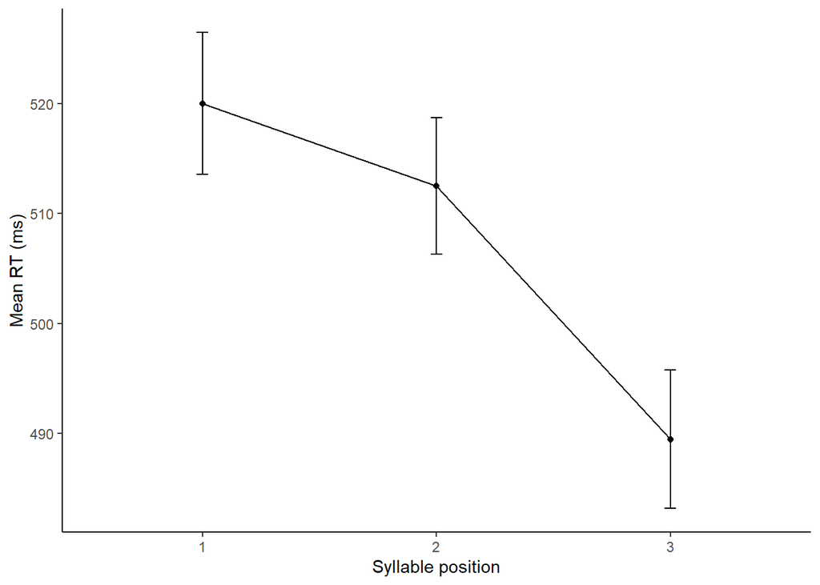

```r
# Plot
position_plot = ggplot(sum_pos, aes(x=Position, y=mean)) +
  #geom_bar(stat = "identity", fill = 'black', alpha = 0.5, width = 0.5) + #For bar graph
  geom_line(aes(group = 1)) +
  geom_point() +
  ylab('Mean RT (ms)') +
  xlab('Syllable position') +
  geom_errorbar(aes(ymin = mean-CI, ymax = mean+CI, width=0.05)) +
  theme(axis.line = element_line(color = 'black')) +
## Uncomment for a blank background
  theme(panel.grid.major = element_blank(), panel.grid.minor = element_blank(), panel.background = element_blank(), axis.line = element_line(colour = "black"))

position_plot
```

2. Syllable effect

```r
rtdf$Syllable = as.factor(rtdf$Syllable)

confidence_interval = function(x){ # Function that calculates the 95% confidence interval of distribution x
  qnorm(.95) * (sd(x)/sqrt(length(x)))
}

# Summarize based on syllable position
sum_syl = rtdf %>%
  dplyr::group_by(Syllable) %>%
  dplyr::summarise(mean = mean(RT), CI = confidence_interval(RT))
```

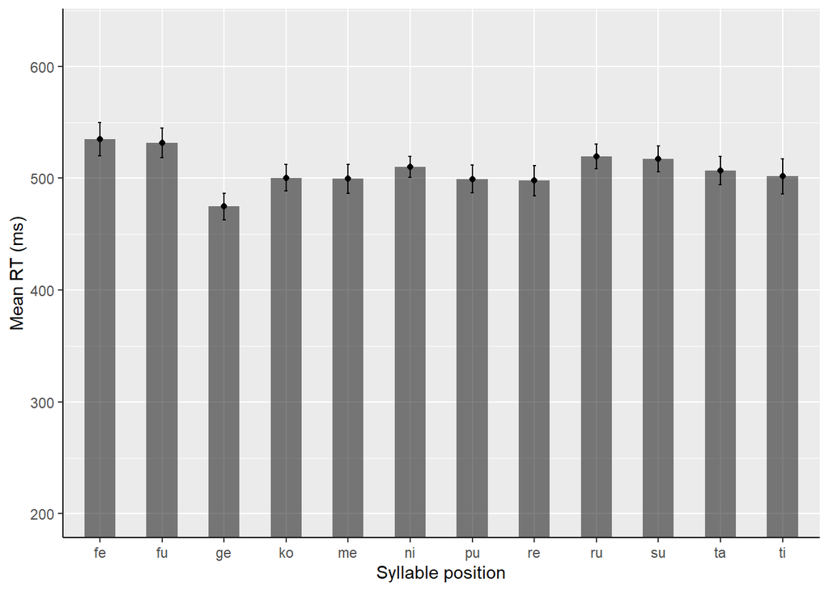

```r
# Plot
syllable_plot = ggplot(sum_syl, aes(x=Syllable, y=mean)) +
  geom_bar(stat = "identity", fill = 'black', alpha = 0.5, width = 0.5) + #For bar graph
  #geom_line(aes(group = 1)) +
  geom_point() +
  ylab('Mean RT (ms)') +
  xlab('Syllable position') +
  coord_cartesian(ylim=c(200, 630)) +
  geom_errorbar(aes(ymin = mean-CI, ymax = mean+CI, width=0.05)) +
  theme(axis.line = element_line(color = 'black'))
## Uncomment for a blank background
  #theme(panel.grid.major = element_blank(), panel.grid.minor = element_blank(), panel.background = element_blank(), axis.line = element_line(colour = "black"))

syllable_plot
```

```r
summary(rtdf)
```

```
##        RT            Syllable    Position   Occurrence   Subject
##  Min.   :   0.9   ru     : 390   1:1486   Min.   :1    Length:4433
##  1st Qu.: 421.1   ge     : 382   2:1478   1st Qu.:1    Class :character
##  Median : 486.4   me     : 382   3:1469   Median :2    Mode  :character
##  Mean   : 507.4   ni     : 382            Mean   :2
##  3rd Qu.: 572.2   re     : 381            3rd Qu.:3
##  Max.   :1197.3   ko     : 379            Max.   :3
##                   (Other):2137
##    Condition     Age      Coded_Position Coded_Occurrence Coded_Condition
##  Min.   :1.000   0:2037   1:1486         1:1476           1:1287
##  1st Qu.:1.000   1:2396   2:1478         2:1483           3:1909
##  Median :3.000            3:1469         3:1474           5:1237
##  Mean   :2.977
##  3rd Qu.:5.000
##  Max.   :5.000
##
```

3. Occurrence x Position interaction

```r
rtdf$Occurrence = as.factor(rtdf$Occurrence)
rtdf$Position = as.numeric(rtdf$Position)

confidence_interval = function(x){ # Function that calculates the 95% confidence interval of distribution x
  qnorm(.95) * (sd(x)/sqrt(length(x)))
}

# Summarize based on syllable position
#positions = c(sum_OP$mean_1, sum_OP$mean_2, sum_OP$mean_3)

sum_PO = rtdf %>%
  dplyr::group_by(Position, Occurrence) %>%
  dplyr::summarise(mean = mean(RT), CI = confidence_interval(RT)) %>%
  pivot_wider(names_from = 'Occurrence', values_from = c('mean', 'CI'))
```

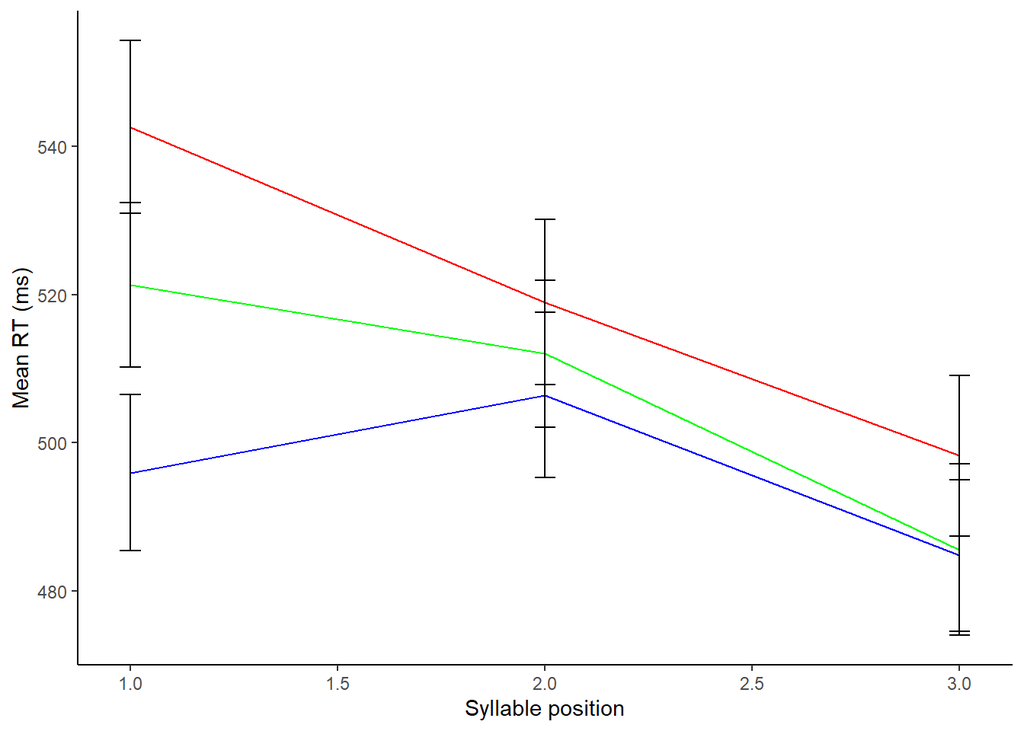

```r
# Plot
ggplot(sum_PO, aes(x=Position)) +
  #geom_bar(stat = "identity", fill = 'black', alpha = 0.5, width = 0.5) + #For bar graph
  geom_line(aes(y=mean_1), color = 'blue') +
  geom_line(aes(y=mean_2), color = 'green') +
  geom_line(aes(y=mean_3), color = 'red') +
  ylab('Mean RT (ms)') +
  xlab('Syllable position') +
  geom_errorbar(aes(ymin = mean_1-CI_1, ymax = mean_1+CI_1, width=0.05)) +
  geom_errorbar(aes(ymin = mean_2-CI_2, ymax = mean_2+CI_2, width=0.05)) +
  geom_errorbar(aes(ymin = mean_3-CI_3, ymax = mean_3+CI_3, width=0.05)) +
  theme(axis.line = element_line(color = 'black')) +
## Uncomment for a blank background
  theme(panel.grid.major = element_blank(), panel.grid.minor = element_blank(), panel.background = element_blank(), axis.line = element_line(colour = "black"))
```

```r
#OP_plot
```

4. d-prime distributions

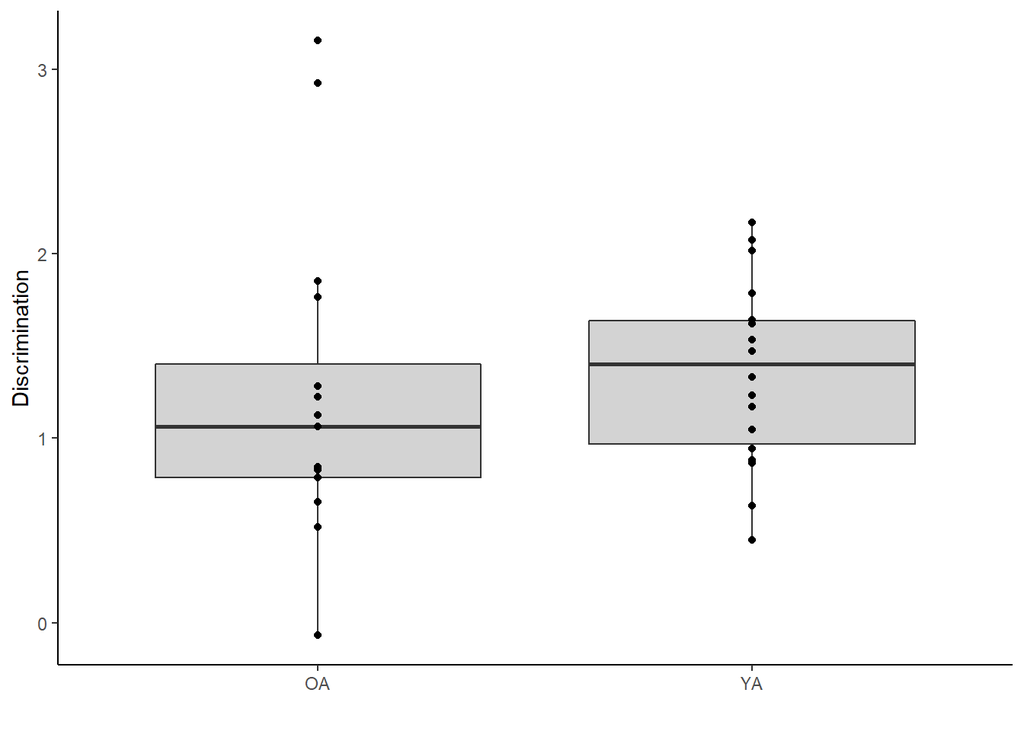

```r
plot_disc = ggplot(df, aes(x = Age, y = Disc), narm = TRUE) +
  geom_boxplot(fill='light gray') +
  geom_point() +
  ylab("Discrimination") +
  xlab("") +
  theme(axis.line = element_line(color = 'black')) +
  theme(panel.grid.major = element_blank(), panel.grid.minor = element_blank(), panel.background = element_blank(), axis.line = element_line(colour = "black"))

plot_recog = ggplot(df, aes(x = Age, y = Recog), narm = TRUE) +
  geom_boxplot(fill='light gray') +
  geom_point() +
  ylab("Recognition") +
  xlab("") +
  theme(axis.line = element_line(color = 'black')) +
  theme(panel.grid.major = element_blank(), panel.grid.minor = element_blank(), panel.background = element_blank(), axis.line = element_line(colour = "black"))

plot_disc
```

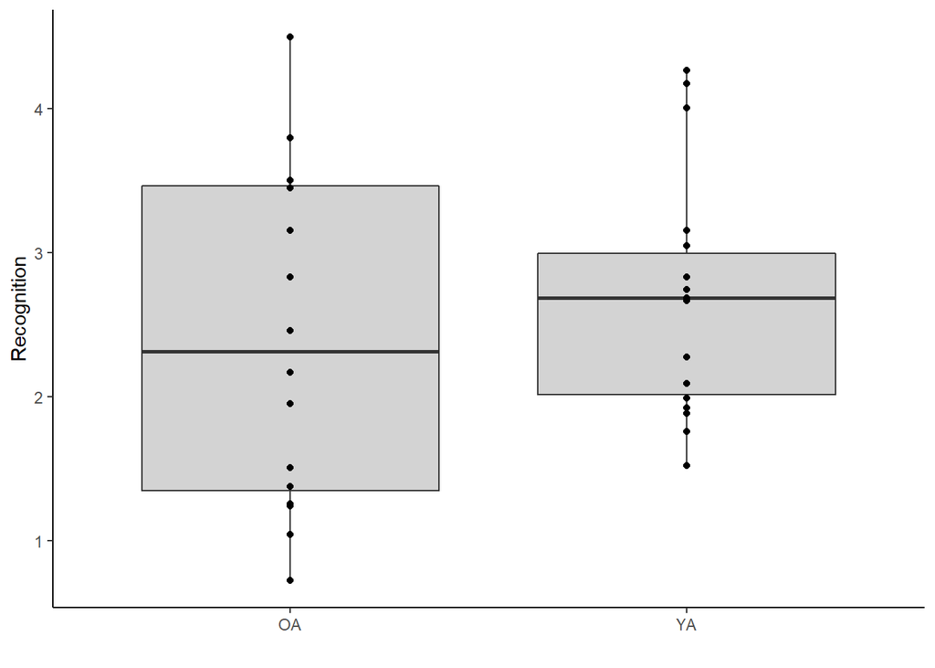

```r
plot_recog
```

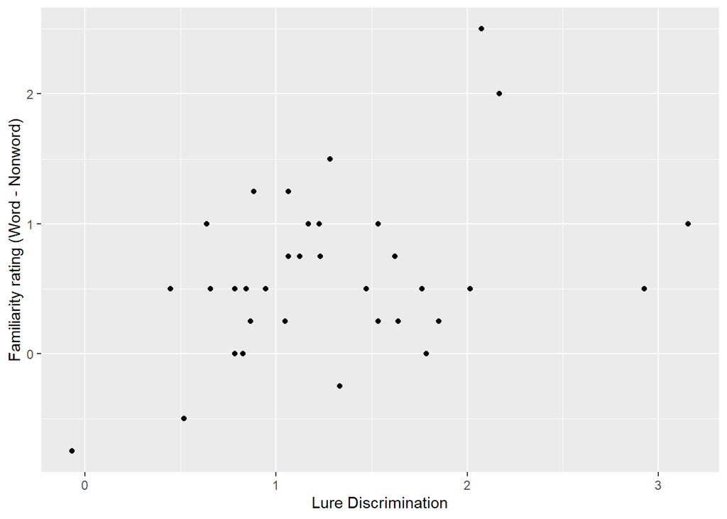

```r
ggplot(df, aes(x=Disc, y=Fam.Diff)) +
  geom_point() +
  ylab("Familiarity rating (Word - Nonword)") +
  xlab("Lure Discrimination")
```

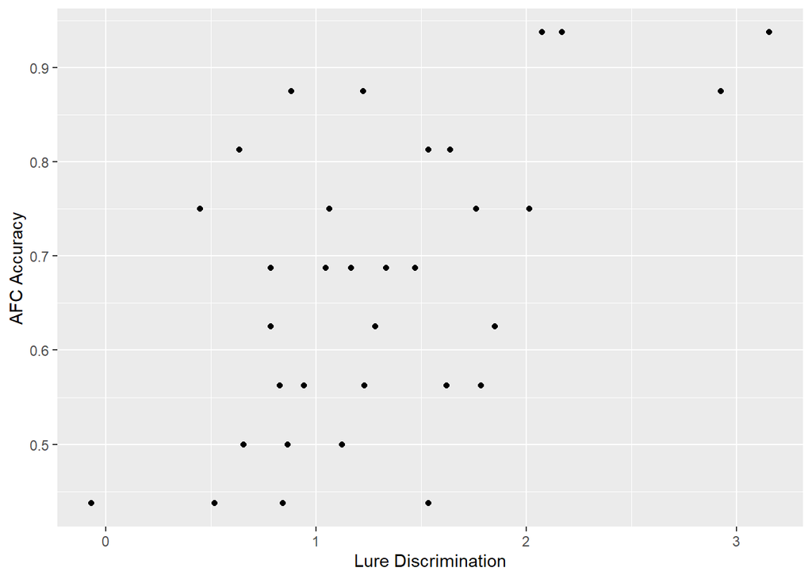

```r
ggplot(df, aes(x=Disc, y=AFC)) +
  geom_point() +
  ylab("AFC Accuracy") +
  xlab("Lure Discrimination")
```

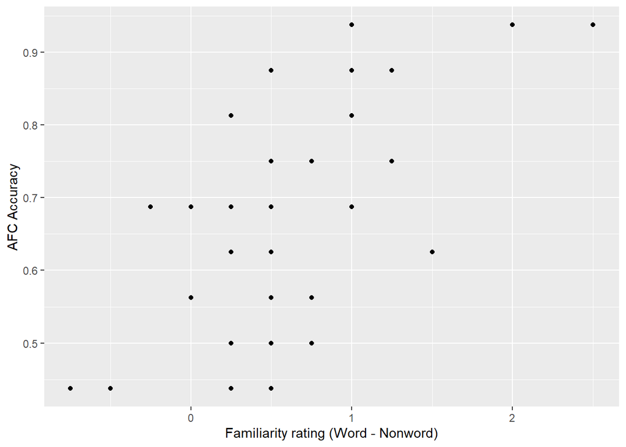

```r
ggplot(df, aes(x=Fam.Diff, y=AFC)) +
  geom_point() +
  xlab("Familiarity rating (Word - Nonword)") +
  ylab("AFC Accuracy")
```